# recruitment data as of 09/11/2026

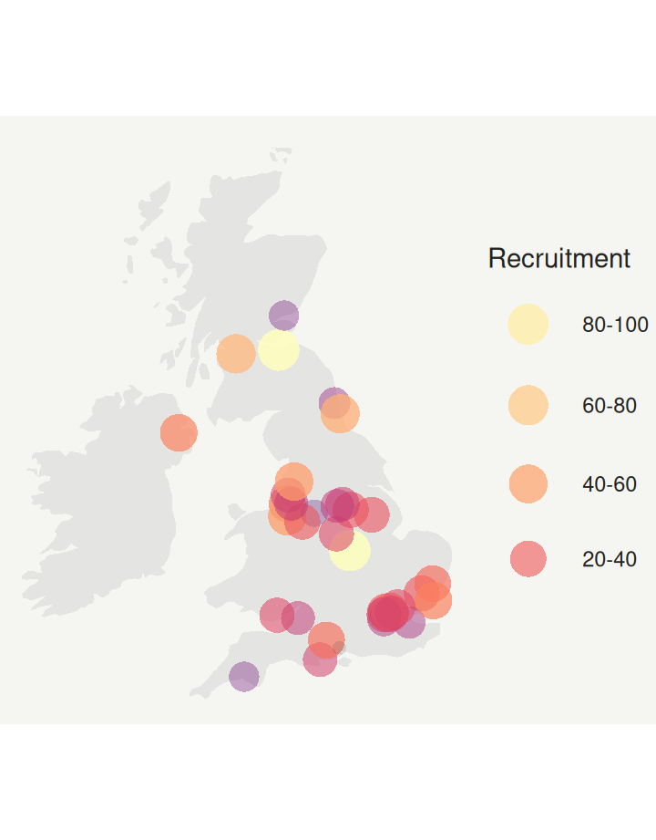

[figure not shown]

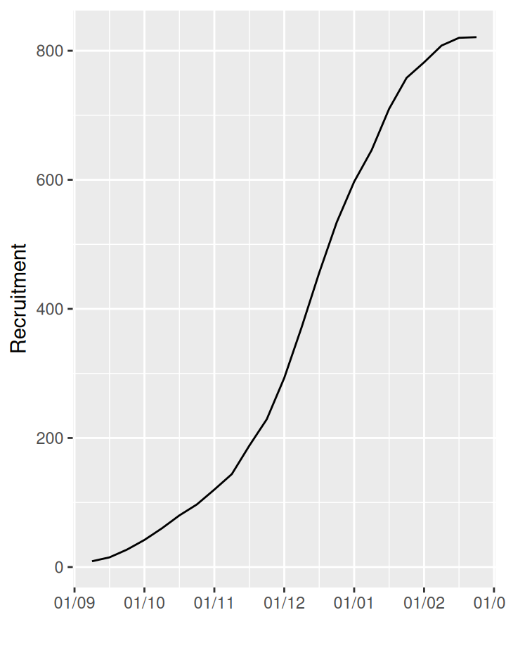

### Leaderboard

BronchStop recruitment by site

| Rank | Site Name | Total |
| --- | --- | --- |
| 1 | Leicester | 93 |
| 2 | Edinburgh | 92 |
| 3 | Glasgow | 49 |
| 4 | Sunderland | 44 |
| 5 | Countess of Chester | 37 |
| 6 | Preston | 37 |
| 7 | Belfast | 29 |
| 8 | Oxford | 28 |
| 9 | Alder Hey | 26 |
| 10 | Salisbury | 24 |

### All Sites

BronchStop recruitment by site

| Site Name | Total |
| --- | --- |
| Alder Hey | 26 |
| Barnet | 16 |
| Belfast | 29 |
| Bristol | 11 |
| Cardiff | 15 |
| Colchester | 19 |
| Countess of Chester | 37 |
| Derby | 15 |
| Doncaster | 19 |
| Dundee | 5 |
| East Cheshire | 3 |
| Edinburgh | 92 |
| Evelina | 5 |
| Glasgow | 49 |
| Homerton | 12 |
| Imperial | 14 |
| Ipswich | 23 |
| Leicester | 93 |
| Leighton | 19 |
| Medway | 8 |
| Newham | 16 |
| North Lincolnshire | 18 |
| Northumbria | 7 |
| Ormskirk | 14 |
| Oxford | 28 |
| Poole | 13 |
| Preston | 37 |
| Rotherham | 12 |
| Royal Free | 8 |
| Royal London | 17 |
| Salisbury | 24 |
| Sheffield | 11 |
| Southampton | 1 |
| St George's | 9 |
| Sunderland | 44 |
| Whipps Cross | 23 |
| Whiston | 11 |
| Whittington | 19 |

### Map of Sites

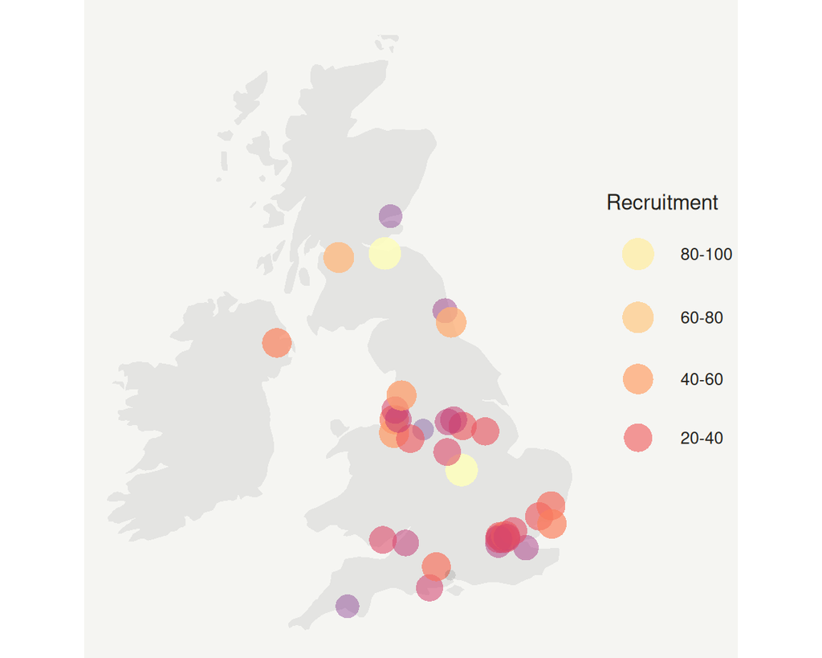

### About

BronchStop is an extension of the [BronchStart study](https://doi.org/10.1093/infdis/jiad551), which initially examined the burden of respiratory disease in children under 2 years in the United Kingdom (UK) and Ireland. Findings from this study provided an estimate of the burden of RSV in the UK and played a role in the JCVI’s recommendation to introduce the maternal RSV vaccination. During the 2024-2025 season, BronchStop successfully evaluated vaccine effectiveness (VE) for the newly introduced maternal RSV vaccine in England and Scotland, and surveyed mothers to understand their views on the vaccine.

For the 2025–2026 season, we are recruiting infants under six months old admitted with respiratory illness and determining whether their mothers were vaccinated against RSV. The protocol for the 2025-2026 season is available [here](https://openresearch.nihr.ac.uk/articles/5-85/v1).

### Outputs

1. Our early report of parent’s views on the RSV vaccine Maternal views on RSV vaccination during the first season of implementation in England and Scotland- The Lancet Infectious Diseases.
2. Our vaccine effectiveness (VE) results from the 2024-2025 season: the first real-world assessment of maternal RSV VE from a high-income country: Bivalent prefusion F vaccination in pregnancy and respiratory syncytial virus hospitalisation in infants in the UK: results of a multicentre, test-negative, case-control study- The Lancet Child and Adolescent Health.
3. A Radio 4 episode about the Born in Bradford cohort study. [Born in Bradford - Gasping for breath](https://www.bbc.co.uk/sounds/play/m0025cxn).
4. One of our study team, Dr Simon Drysdale contributed to this Royal College of Paediatrics podcast discussing the maternal RSV vaccine [The Paeds Round - Protecting infants with the maternal vaccine for RSV](https://learning.rcpch.ac.uk/home/podcasts/the-paeds-round-from-rcpch-and-medisense/).
5. World Health Organization position paper on RSV immunisation [citing the BronchStop study](https://www.who.int/publications/i/item/WER10022).
6. [Transcript of a House of Lords debate citing the results from the BronchStop study](https://hansard.parliament.uk/lords/2025-09-09/debates/0AD30E5C-A3AA-40A4-A743-F7B655F06EB3/RespiratorySyncytialVirusVaccinationProgramme).
7. [News piece in The Sun newspaper on the results from the BronchStop study](https://www.thesun.co.uk/health/35915701/cases-deadly-lung-virus-rsv-babies-plummets-vaccine/).

### Virus Detections

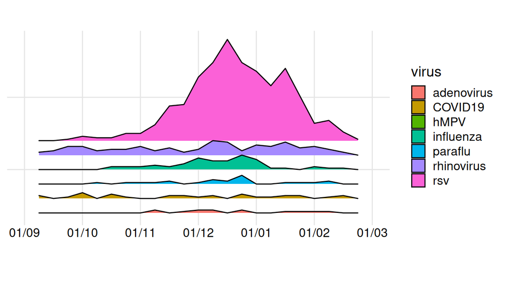

### Cumulative Recruitment

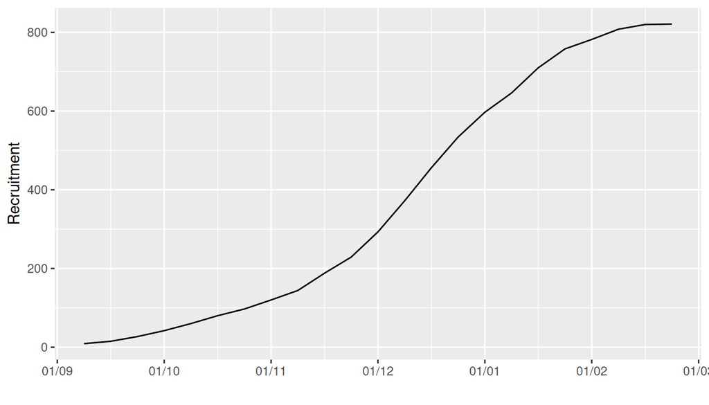